# DATA 605 - Final Project

#### Scatter plots

rovide a scatterplot matrix for at least two of the independent variables and the dependent variable

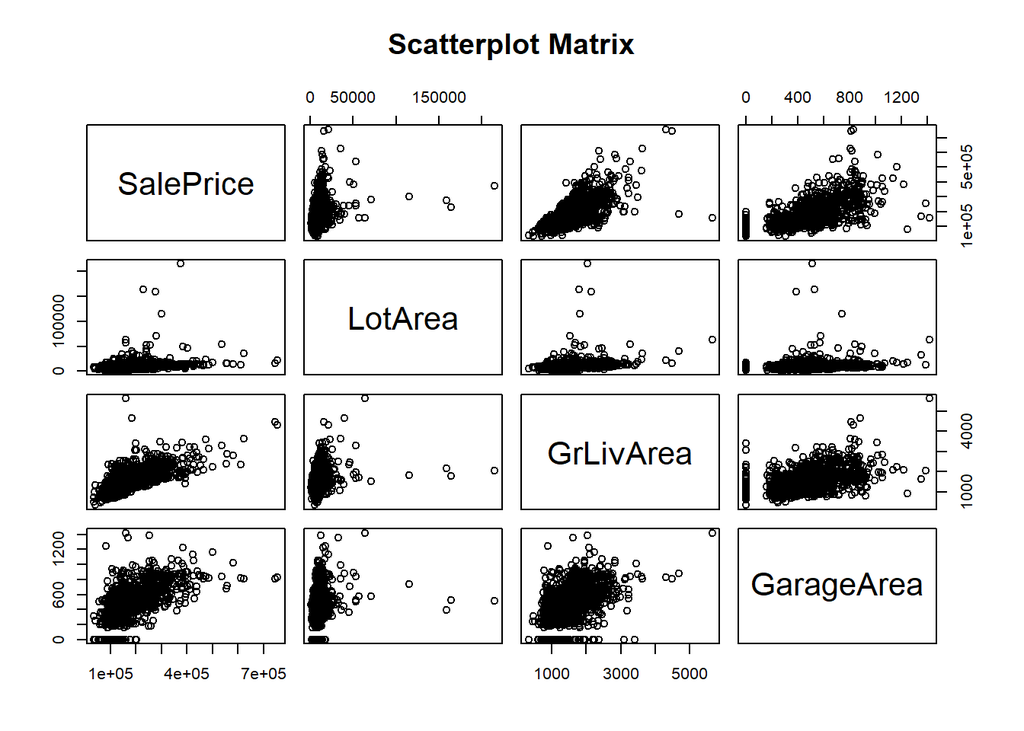

```r
#ScatterPlot
pairs(~SalePrice+LotArea+GrLivArea++GarageArea,data=train, main="Scatterplot Matrix")
```

#### Correlation Matrix  
Derive a correlation matrix for any three quantitative variables in the dataset. Test the hypotheses that the correlations between each pairwise set of variables is 0 and provide an 80% confidence interval. Discuss the meaning of your analysis. Would you be worried about familywise error? Why or why not?

```r
#Subsetting data
sub_df <- data.frame(train$LotArea,train$GrLivArea,train$GarageArea)
#Correlation
cormatrix <- cor(sub_df)
cormatrix
```

```
##                  train.LotArea train.GrLivArea train.GarageArea
## train.LotArea        1.0000000       0.2631162        0.1804028
## train.GrLivArea      0.2631162       1.0000000        0.4689975
## train.GarageArea     0.1804028       0.4689975        1.0000000
```

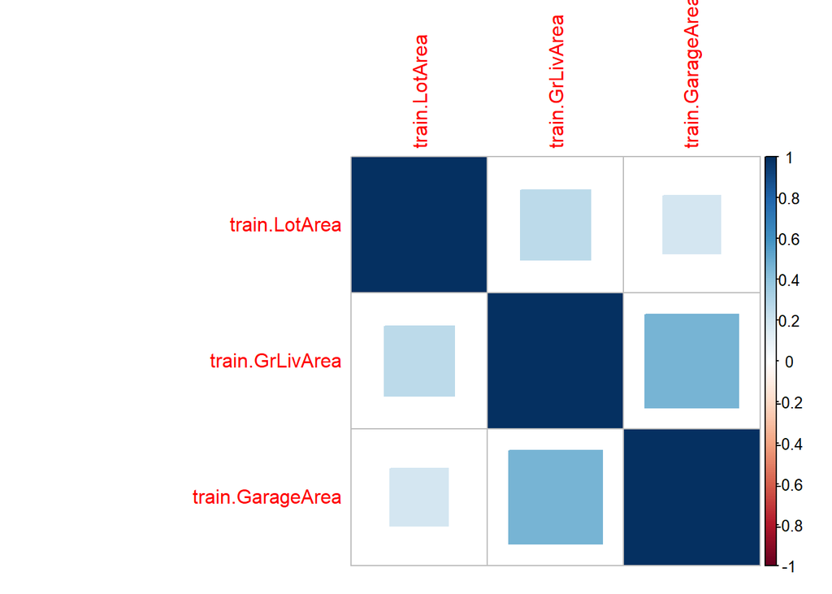

```r
library(corrplot)
corrplot(cormatrix, method="square")
```

#### Hypothesis Test

```r
#GrLivArea & LotArea
cor.test(train$LotArea,train$GrLivArea,method = "pearson",conf.level = 0.80)
```

```
##
##  Pearson's product-moment correlation
##
## data:  train$LotArea and train$GrLivArea
## t = 10.414, df = 1458, p-value < 2.2e-16
## alternative hypothesis: true correlation is not equal to 0
## 80 percent confidence interval:
##  0.2315997 0.2940809
## sample estimates:
##       cor
## 0.2631162
```

```r
#GarageArea & LotArea
cor.test(train$LotArea,train$GarageArea,method = "pearson",conf.level = 0.80)
```

```
##
##  Pearson's product-moment correlation
##
## data:  train$LotArea and train$GarageArea
## t = 7.0034, df = 1458, p-value = 3.803e-12
## alternative hypothesis: true correlation is not equal to 0
## 80 percent confidence interval:
##  0.1477356 0.2126767
## sample estimates:
##       cor
## 0.1804028
```

```r
#GarageArea & GrLivArea
cor.test(train$GarageArea,train$GrLivArea,method = "pearson",conf.level = 0.80)
```

```
##
##  Pearson's product-moment correlation
##
## data:  train$GarageArea and train$GrLivArea
## t = 20.276, df = 1458, p-value < 2.2e-16
## alternative hypothesis: true correlation is not equal to 0
## 80 percent confidence interval:
##  0.4423993 0.4947713
## sample estimates:
##       cor
## 0.4689975
```

### Linear Algebra and Correlation

Invert your correlation matrix from above. (This is known as the precision matrix and contains variance inflation factors on the diagonal.) Multiply the correlation matrix by the precision matrix, and then multiply the precision matrix by the correlation matrix. Conduct LU decomposition on the matrix.

#### Invert your correlation matrix from above.

```r
precision_matrix<-solve(cormatrix)
round(precision_matrix,4)
```

```
##                  train.LotArea train.GrLivArea train.GarageArea
## train.LotArea           1.0792         -0.2470          -0.0789
## train.GrLivArea        -0.2470          1.3385          -0.5832
## train.GarageArea       -0.0789         -0.5832           1.2877
```

#### Multiply the matrix

```r
#Correlation matrix by Precision matrix
corr_by_prec <- cormatrix%*%precision_matrix
round(corr_by_prec, 4)
```

```
##                  train.LotArea train.GrLivArea train.GarageArea
## train.LotArea                1               0                0
## train.GrLivArea              0               1                0
## train.GarageArea             0               0                1
```

```r
#precision matrix by the correlation matrix
prec_by_corr <- precision_matrix%*%cormatrix
round(prec_by_corr, 4)
```

```
##                  train.LotArea train.GrLivArea train.GarageArea
## train.LotArea                1               0                0
## train.GrLivArea              0               1                0
## train.GarageArea             0               0                1
```

#### Conduct LU Decomposition

```r
library(matrixcalc)
lu.decomposition(precision_matrix)
```

```
## $L
##             [,1]       [,2] [,3]
## [1,]  1.00000000  0.0000000    0
## [2,] -0.22884393  1.0000000    0
## [3,] -0.07307553 -0.4689975    1
##
## $U
##          [,1]       [,2]        [,3]
## [1,] 1.079209 -0.2469705 -0.07886378
## [2,] 0.000000  1.2819833 -0.60124693
## [3,] 0.000000  0.0000000  1.00000000
```

### Calculus-Based Probability & Statistics

Select a variable in the Kaggle.com training dataset that is skewed to the right, shift it so that the minimum value is absolutely above zero if necessary. Then load the MASS package and run fitdistr to fit an exponential probability density function.

```r
mass_fit <- train$TotalBsmtSF
min(mass_fit)
```

```
## [1] 0
```

#### Fit an exponential probability density function

```r
library(MASS)
```

```r
fit <- fitdistr(mass_fit, "exponential")
fit
```

```
##        rate
##   9.456896e-04
##  (2.474983e-05)
```

Find the optimal value of $\lambda$ for this distribution, and then take 1000 samples from this exponential distribution using this value (e.g., rexp(1000,$\lambda$)).

```r
lambda<-fit$estimate
sim<- rexp(1000,lambda)
lambda
```

```
##         rate
## 0.0009456896
```

#### plot and compare

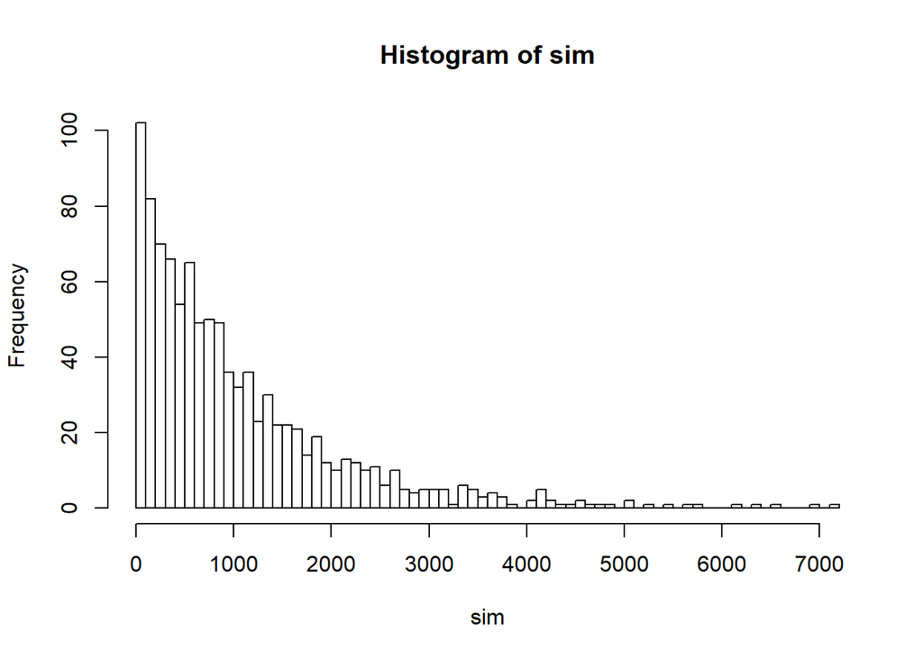

```r
hist(sim,breaks = 100)
```

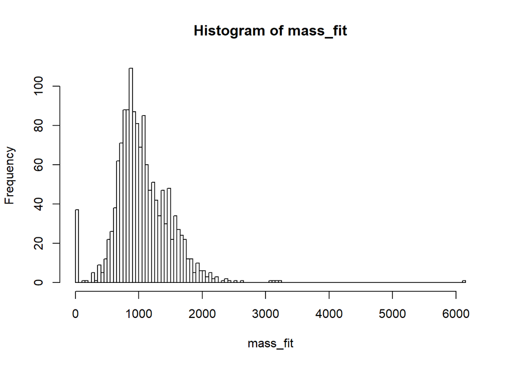

```r
hist(mass_fit, breaks = 100)
```

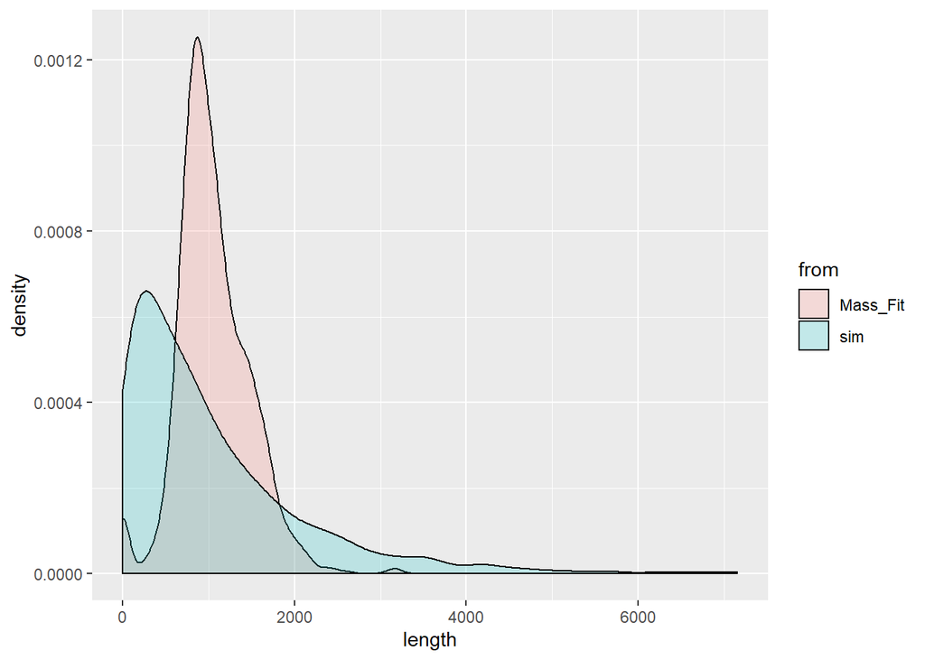

```r
library(ggplot2)
sim.df <- data.frame(length = sim)
mass_fit.df <- data.frame(length = mass_fit)

sim.df$from <- 'sim'
mass_fit.df$from <- 'Mass_Fit'

both.df <- rbind(sim.df,mass_fit.df)

ggplot(both.df, aes(length, fill = from)) + geom_density(alpha = 0.2)
```

#### cumulative distribution function (CDF)

Using the exponential pdf, find the 5th and 95th percentiles using the cumulative distribution function (CDF).

```r
quantile(sim, probs=c(0.05, 0.95))
```

```
##         5%        95%
##   55.16854 3200.41083
```

```r
mean(mass_fit)
```

```
## [1] 1057.429
```

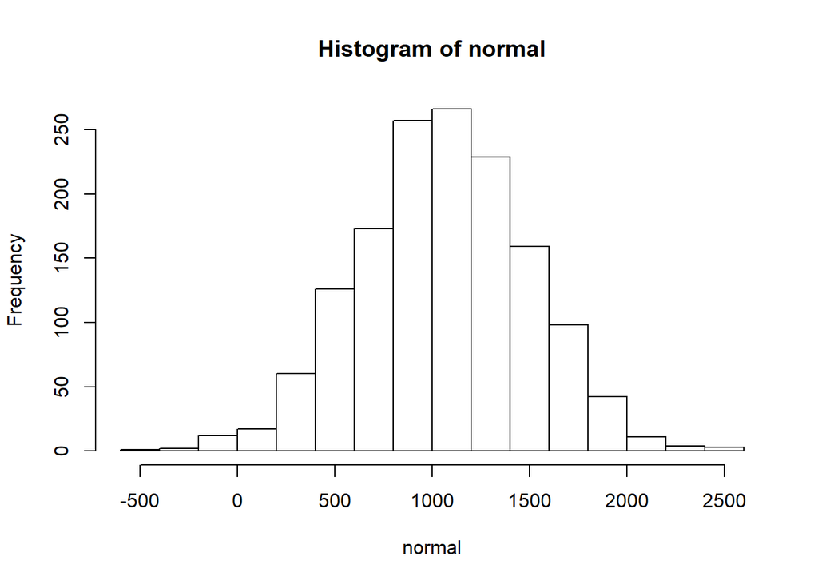

```r
normal<-rnorm(length(mass_fit),mean(mass_fit),sd(mass_fit))
hist(normal)
```

```r
quantile(normal, probs=c(0.05, 0.95))
```

```
##        5%       95%
##  343.4975 1762.2931
```

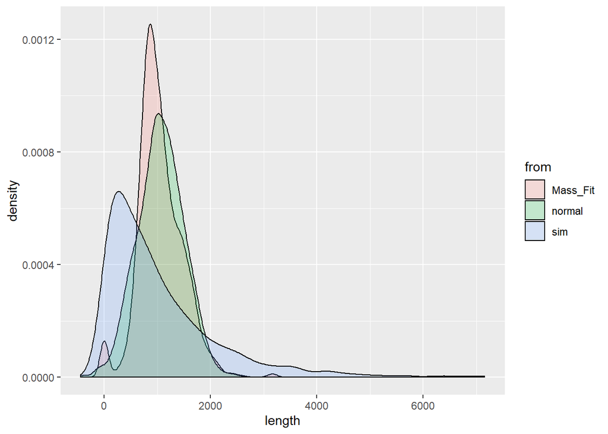

```r
normal.df <- data.frame(length = normal)

normal.df$from <- 'normal'

all.df <- rbind(both.df,normal.df)

ggplot(all.df, aes(length, fill = from)) + geom_density(alpha = 0.2)
```

## Kaggle Submission

Link to my rpub of House Prices(https://rpubs.com/gpadmaperuma/617543)

Username: gpadmaperuma Display Name: Geeth Email: gpadmaperuma@gmail.com Score: 9.45360

[figure not shown]